# BCB420 - Assignment 1

Minh An Ho

## Dataset Information

Publication Title: Age-dependent skeletal muscle transcriptome response to bed rest-induced atrophy.  
Publication Date: 2019-04-01  
Publication Journal: J Appl Physiol  
GEO ID: GSE113165

## Install and Load Dependencies

```r
# check to ensure all needed packages are installed
if (!requireNamespace("BiocManager", quietly = TRUE))
  install.packages("BiocManager")

if (!requireNamespace("GEOquery", quietly = TRUE))
  BiocManager::install("GEOquery")

if (!requireNamespace("biomaRt", quietly = TRUE))
  BiocManager::install("biomaRt")

if (!requireNamespace("edgeR", quietly = TRUE))
  BiocManager::install("edgeR")


if (!requireNamespace("knitr", quietly = TRUE))
  BiocManager::install("knitr")

library(GEOquery)
library(biomaRt)
library(edgeR)
library(knitr)
```

## Load the Dataset

We load our information about our datased using the GEO id, we then extract our desired information to produce our sample set with appropriate labels.

```r
GSE113165 <- GEOquery::getGEO("GSE113165", GSEMatrix =TRUE)

show(GSE113165)
GSE113165_data <- (pData(phenoData(GSE113165[[1]])))

#Create sample set
samples <- data.frame(GSE113165_data$description.1, GSE113165_data$`subject:ch1`, GSE113165_data$`age:ch1`, GSE113165_data$`Sex:ch1`, gsub("susceptibility: ", "", GSE113165_data$characteristics_ch1.5), gsub("time: ", "", GSE113165_data$characteristics_ch1.1))
colnames(samples) <- c("id", "subject","age", "sex", "susceptibility", "time")

#Create sample set
samples <- data.frame(GSE113165_data$`subject:ch1`, GSE113165_data$`age:ch1`, GSE113165_data$`Sex:ch1`, gsub("susceptibility: ", "", GSE113165_data$characteristics_ch1.5), gsub("time: ", "", GSE113165_data$characteristics_ch1.1))
samples <- t(samples)
colnames(samples) <- GSE113165_data$description.1
rownames(samples) <- c("subject","age", "sex", "susceptibility", "time")
```

Expression count data is downloaded and accessed here. Formatted as needed.

```r
#Reading in supplementary files with expression counts
sfiles <- getGEOSuppFiles('GSE113165')
fnames <- rownames(sfiles)
expCounts <- read.delim(fnames[1],header=TRUE, check.names = FALSE)
```

```r
#Preview of data
kable(head(expCounts))
```

| geneid | 10876X1 | 10876X2 | 10876X3 | 10876X4 | 10876X5 | 10876X6 | 10876X7 | 10876X8 | 10876X9 | 14406X1 | 14406X2 | 14406X3 | 14406X4 | 14406X5 | 14406X6 | 14406X7 | 14406X8 | 14406X9 | 10876X10 | 10876X11 | 10876X12 | 10876X13 | 10876X14 | 10876X15 | 10876X16 | 10876X17 | 10876X18 | 10876X19 | 10876X20 | … |
| --- | --- | --- | --- | --- | --- | --- | --- | --- | --- | --- | --- | --- | --- | --- | --- | --- | --- | --- | --- | --- | --- | --- | --- | --- | --- | --- | --- | --- | --- | --- |
| ENSG00000000003 | 49 | 33 | 51 | 25 | 54 | 42 | 30 | 28 | 61 | 67 | 51 | 63 | 49 | 59 | 72 | 42 | 51 | 87 | 33 | 17 | 14 | 34 | 38 | 65 | 67 | 111 | 93 | 32 | 41 | … |
| ENSG00000000005 | 1 | 0 | 1 | 0 | 0 | 0 | 1 | 0 | 1 | 2 | 1 | 0 | 1 | 1 | 2 | 10 | 0 | 4 | 0 | 0 | 0 | 1 | 0 | 2 | 4 | 2 | 2 | 2 | 1 | … |
| ENSG00000000419 | 207 | 224 | 236 | 102 | 298 | 167 | 115 | 109 | 268 | 352 | 298 | 359 | 288 | 278 | 624 | 279 | 285 | 404 | 181 | 143 | 63 | 185 | 189 | 299 | 183 | 449 | 396 | 90 | 110 | … |
| ENSG00000000457 | 136 | 112 | 118 | 94 | 194 | 169 | 106 | 96 | 169 | 176 | 220 | 196 | 222 | 243 | 297 | 216 | 212 | 265 | 141 | 115 | 103 | 108 | 134 | 174 | 165 | 265 | 276 | 95 | 146 | … |
| ENSG00000000460 | 23 | 19 | 26 | 21 | 39 | 32 | 20 | 18 | 45 | 69 | 68 | 48 | 59 | 46 | 65 | 88 | 98 | 82 | 30 | 12 | 24 | 18 | 16 | 37 | 32 | 73 | 76 | 30 | 34 | … |
| ENSG00000000938 | 27 | 7 | 7 | 5 | 29 | 8 | 9 | 10 | 7 | 15 | 24 | 17 | 14 | 43 | 36 | 27 | 12 | 25 | 25 | 76 | 33 | 7 | 6 | 7 | 15 | 26 | 55 | 15 | 14 | … |

## Clean the Data

Here we remove genes with low expression count to clean up the dataset.

```r
dim(expCounts)
```

```
## [1] 58051    57
```

```r
#Removing low counts
cpms <- cpm(expCounts[2:57])
rownames(cpms) <- expCounts[,1]
keep <- rowSums(cpms >1) >=3
expCounts_filtered <- expCounts[keep,]

dim(expCounts_filtered)
```

```
## [1] 16674    57
```

## Normalization

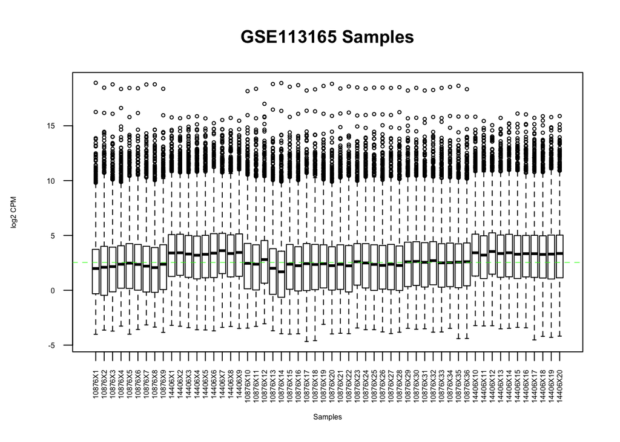

```r
#Original Box Plot
data2plot <- log2(cpm(expCounts_filtered[2:57]))
boxplot(data2plot, xlab = "Samples", ylab = "log2 CPM",
        las = 2, cex = 0.5, cex.lab = 0.5,
        cex.axis = 0.5, main = "GSE113165 Samples")
abline(h = median(apply(data2plot, 2, median)), col = "green", lwd = 0.6, lty = "dashed")
```

We will apply TMM (Trimmed Mean of M-Values) to normalize the filtered data. As you can see, the plot (and of course the data) adjusts so all the samples have a similar mean.

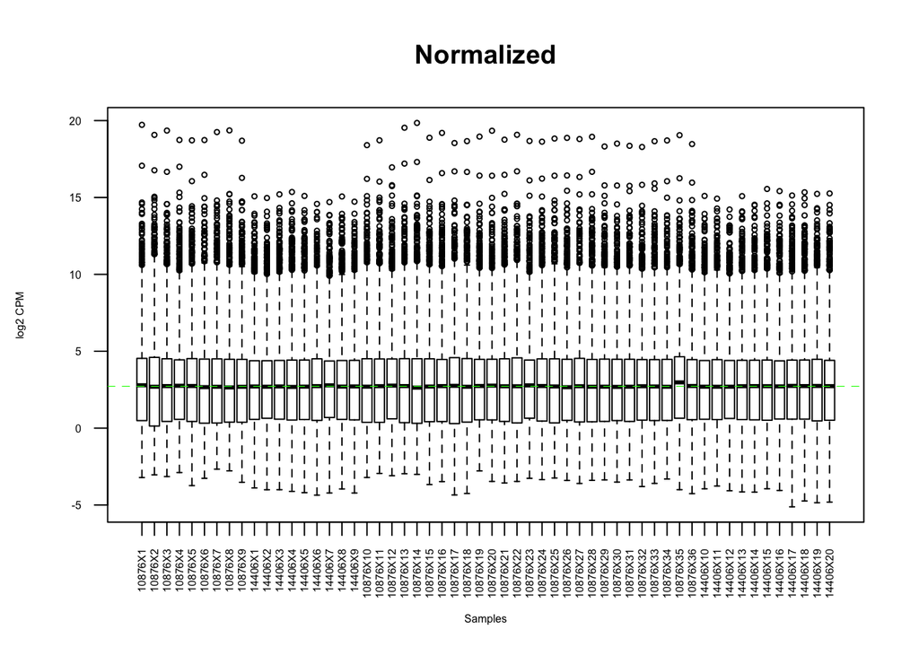

```r
#Normalization
filtered_data_matrix <- as.matrix(expCounts_filtered[2:57])
rownames(filtered_data_matrix) <- expCounts_filtered$geneid
d = DGEList(counts=filtered_data_matrix, group=samples["time",])
d = calcNormFactors(d)
normalized_counts <- cpm(d)

#Normalized Box Plot
data2plot <- log2(normalized_counts)
boxplot(data2plot, xlab = "Samples", ylab = "log2 CPM",
        las = 2, cex = 0.5, cex.lab = 0.5,
        cex.axis = 0.5, main = "Normalized")
abline(h = median(apply(data2plot, 2, median)), col = "green", lwd = 0.6, lty = "dashed")
```

We can also view the data in terms of a density plot, before and after normalization. We can see that the distribution (sample lines) are tighter and more similar.

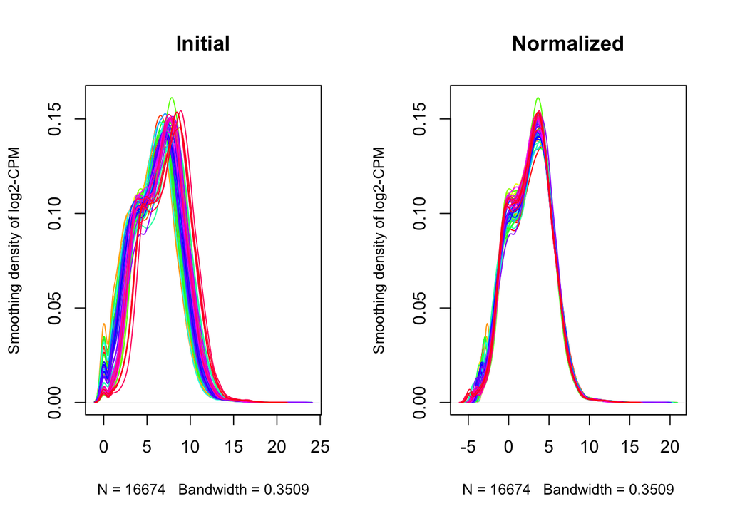

```r
#Density Plot
counts_density <- apply(log2(filtered_data_matrix), 2, density)
#Calculate the Limits
xlim <- 0; ylim <- 0
for (i in 1:length(counts_density)) {
        xlim <- range(c(xlim, counts_density[[i]]$x));
        ylim <- range(c(ylim, counts_density[[i]]$y))
}

cols <- rainbow(length(counts_density))
ltys <- rep(1, length(counts_density))

#plot the first density plot to initialize the plot
par(fig=c(0,0.5,0,1), new=FALSE)
plot(counts_density[[1]], xlim=xlim, ylim=ylim, type="n",
     ylab="Smoothing density of log2-CPM", main="Initial", cex.lab = 0.85)
#plot each line
for (i in 1:length(counts_density)) lines(counts_density[[i]], col=cols[i], lty=ltys[i])

normalized_counts_density <- apply(log2(normalized_counts), 2, density)
#Calculate the Mormalized Limits
xlim <- 0; ylim <- 0
for (i in 1:length(normalized_counts_density)) {
        xlim <- range(c(xlim, normalized_counts_density[[i]]$x));
        ylim <- range(c(ylim, normalized_counts_density[[i]]$y))
}

cols <- rainbow(length(normalized_counts_density))
ltys <- rep(1, length(normalized_counts_density))

#Normalized Density Plot
par(fig=c(0.50,1,0,1), new=TRUE)
plot(normalized_counts_density[[1]], xlim=xlim, ylim=ylim, type="n",
     ylab="Smoothing density of log2-CPM", main="Normalized", cex.lab = 0.85)
for (i in 1:length(normalized_counts_density)) lines(normalized_counts_density[[i]], col=cols[i], lty=ltys[i])
```

## Visualize the data

I didn’t use labels in this case as it crowded the MDS visual.

In this case the samples are grouped in pre and post bed rest. There seems to some clustering between -0.5 and -1.0 of the x-axis, as well as 1.0 and 1.5, but it is difficult to see if one group is more prominent than another in the grouping.

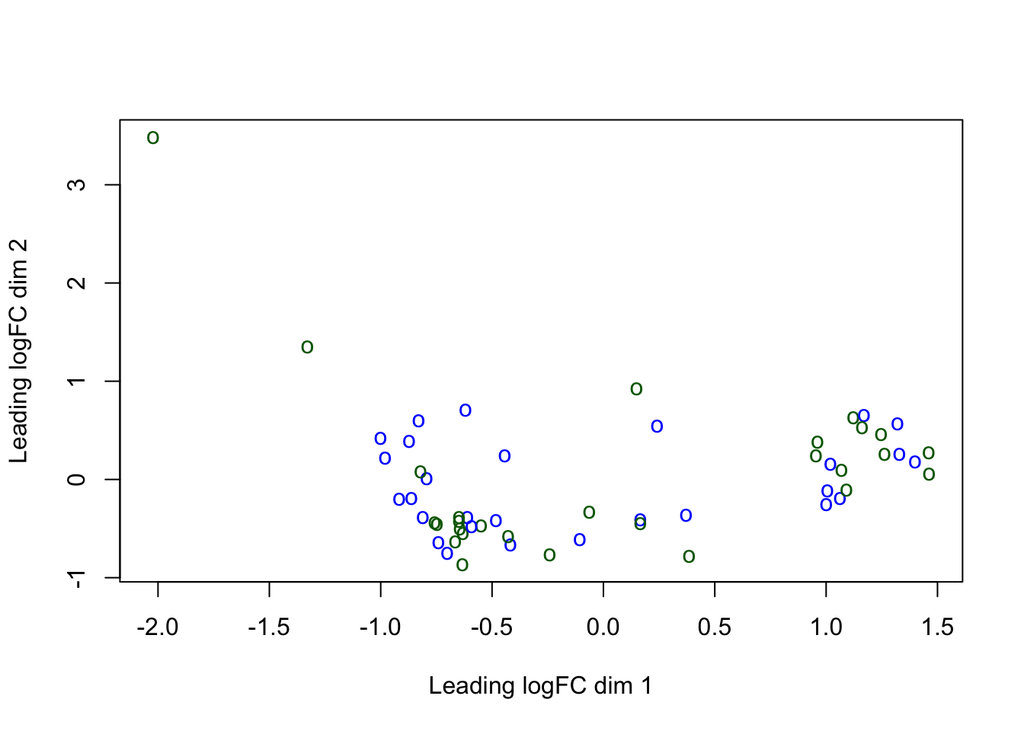

```r
plotMDS(d, labels="o",
        col = c("darkgreen","blue")[factor(samples["time",])])
```

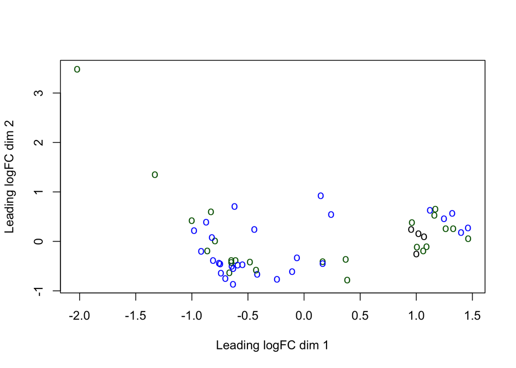

```r
plotMDS(d, labels="o",
        col = c("darkgreen","blue")[factor(samples["susceptibility",])])
```

Perhaps age is also a factor, let’s visualize this. This group clusering is even more distinguishable here, showing the shared expression profiles of the age groups.

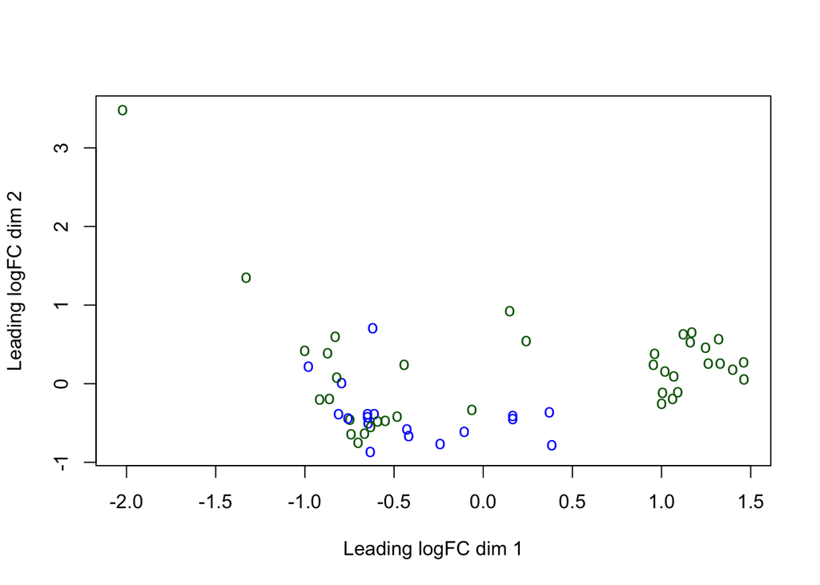

```r
plotMDS(d, labels="o",
        col = c("darkgreen","blue")[factor(samples["age",])])
```

## HUGO Identifier Mapping

We now map the ENSEMBL gene ids to HUGO (hgnc) identifiers using biomart, particularly the getGM function.

```r
#Adding another column to normalized_counts for ease of merging later
ensembl_labels <- data.frame(rownames(normalized_counts))
colnames(ensembl_labels) <- "ensembl_gene_id"
normalized_counts <- cbind(normalized_counts, ensembl_labels)

#Loading emsembl human data
mart <- useEnsembl(biomart = "ensembl",
                   dataset = "hsapiens_gene_ensembl",
                   mirror = "useast")

#Retreive HUGO symbols for each ENSEMBL ID and set as new rownames
sample_HUGO <- getBM(attributes = c("ensembl_gene_id", "hgnc_symbol"), filters = "ensembl_gene_id", values = c(expCounts_filtered[1]), mart = mart)
```

Some of the gene ids are not returned by getGM (depreciated or no symbol available) so these are not included in the dataset after merging with the returned ids.

```r
#Integrating into counts
normalized_counts_annot <- merge(sample_HUGO,normalized_counts, by.x="ensembl_gene_id", by.y="ensembl_gene_id", all.y=FALSE)
```

In addition, some of these returned gene ids have been returned with an empty string for the HUGO identifier, and these are also removed from the dataset.

```r
#Empty HUGO Removal
nonempty_HUGO <- normalized_counts_annot["" != normalized_counts_annot[, 2],]
```

I also realized that there may be duplicate HUGO ids, so we remove the replicates and only keep a mean of the expression values. This means that as a result there is no ENSEMBL id associated with these expression values, this may cause an issue later, but we can always adjust this to map to one of the duplicate ids.

```r
#Unique HUGO symbols only
HUGO_duplicate_name <- nonempty_HUGO[duplicated(nonempty_HUGO[,2]),2]

for (x in HUGO_duplicate_name){
  dup_index <- which(x == nonempty_HUGO[,2])

  #Store ENSEMBL ID
  dup_ENSEMBL <- nonempty_HUGO[dup_index, 1]

  #Mean expression values
  replacement_dup <- data.frame(t(colMeans(nonempty_HUGO[dup_index, 3:58])))
  colnames(replacement_dup) <- gsub(colnames(replacement_dup), pattern="^X", replace="")

  #Save associated ids
  replacement_dup[,"ensembl_gene_id"] <- ""
  replacement_dup[,"hgnc_symbol"] <- HUGO_duplicate_name[x]

  #Remove duplicate rows
  removed_dup <- nonempty_HUGO[-dup_index,]

  #Add meaned duplicates back
  unique_counts <- rbind(removed_dup, replacement_dup)
}

#Preview into the dataset
kable(head(unique_counts))
```

| ensembl_gene_id | hgnc_symbol | 10876X1 | 10876X2 | 10876X3 | 10876X4 | 10876X5 | 10876X6 | 10876X7 | 10876X8 | 10876X9 | 14406X1 | 14406X2 | 14406X3 | 14406X4 | 14406X5 | 14406X6 | 14406X7 | 14406X8 | 14406X9 | 10876X10 | 10876X11 | 10876X12 | 10876X13 | 10876X14 | 10876X15 | 10876X16 | 10876X17 | 10876X18 | 10876X19 | … |
| --- | --- | --- | --- | --- | --- | --- | --- | --- | --- | --- | --- | --- | --- | --- | --- | --- | --- | --- | --- | --- | --- | --- | --- | --- | --- | --- | --- | --- | --- | --- |
| ENSG00000000003 | TSPAN6 | 5.289463 | 4.025953 | 5.7483737 | 3.3755463 | 4.052595 | 4.3699835 | 4.722525 | 4.079050 | 5.3109728 | 4.517023 | 3.174709 | 3.927295 | 2.8252135 | 3.221141 | 3.513752 | 2.258656 | 3.2873595 | 4.672469 | 3.570428 | 2.206914 | 1.638454 | 4.3521590 | 4.7169699 | 5.1087359 | 6.016743 | 5.454376 | 4.884660 | 4.648841 | … |
| ENSG00000000419 | DPM1 | 22.345283 | 27.327681 | 26.6003176 | 13.7722291 | 22.364322 | 17.3758868 | 18.103013 | 15.879157 | 23.3334541 | 23.731228 | 18.550263 | 22.379349 | 16.6053366 | 15.177579 | 30.452516 | 15.003933 | 18.3705385 | 21.697441 | 19.583254 | 18.564045 | 7.373045 | 23.6808651 | 23.4607189 | 23.5001852 | 16.433791 | 22.063195 | 20.799196 | 13.074864 | … |
| ENSG00000000457 | SCYL3 | 14.680959 | 13.663840 | 13.3001588 | 12.6920542 | 14.559324 | 17.5839812 | 16.686256 | 13.985313 | 14.7140065 | 11.865614 | 13.694825 | 12.218252 | 12.7999469 | 13.266733 | 14.494226 | 11.615948 | 13.6651023 | 14.232232 | 15.255463 | 14.929127 | 12.054343 | 13.8245050 | 16.6335256 | 13.6756931 | 14.817353 | 13.021707 | 14.496409 | 13.801245 | … |
| ENSG00000000460 | C1orf112 | 2.482809 | 2.317973 | 2.9305435 | 2.8354589 | 2.926874 | 3.3295112 | 3.148350 | 2.622246 | 3.9179307 | 4.651860 | 4.232946 | 2.992225 | 3.4017877 | 2.511398 | 3.172137 | 4.732423 | 6.3168869 | 4.403936 | 3.245843 | 1.557822 | 2.808779 | 2.3040842 | 1.9860926 | 2.9080497 | 2.873668 | 3.587112 | 3.991765 | 4.358288 | … |
| ENSG00000000938 | FGR | 2.914602 | 0.853990 | 0.7889925 | 0.6751093 | 2.176394 | 0.8323778 | 1.416758 | 1.456803 | 0.6094559 | 1.011274 | 1.493981 | 1.059746 | 0.8072039 | 2.347611 | 1.756876 | 1.451993 | 0.7734964 | 1.342663 | 2.704869 | 9.866206 | 3.862071 | 0.8960327 | 0.7447847 | 0.5501716 | 1.347032 | 1.277602 | 2.888777 | 2.179144 | … |
| ENSG00000000971 | CFH | 38.861361 | 16.713805 | 26.8257441 | 23.3587807 | 35.872973 | 34.1274902 | 35.104104 | 18.647084 | 40.6594144 | 29.866290 | 29.817369 | 27.179376 | 20.8143281 | 22.984751 | 27.085171 | 26.135883 | 33.9049236 | 35.714847 | 32.891211 | 27.651340 | 12.054343 | 27.2649960 | 17.2541795 | 28.6875171 | 25.324203 | 17.493312 | 19.433592 | 24.987518 | … |

## Interpret and Document

**What are the control and test conditions of the dataset?**

Control condition: Vastus lateralis cells of YOUNG (N=9) and OLD (N=18) men and women before five days of bed rest

Test condition: Vastus lateralis cells of YOUNG (N=9) and OLD (N=18) men and women after five days of bed rest

**Why is the dataset of interest to you?**

This dataset stood out to me as there are no direct interventions aside from a change in physical behaviour. I usually do not encounter experimental studies that do not incorporate pharmaceutical/biochemical intervention, so I was interested to see the resulting gene expression values.

**Were there expression values that were not unique for specific genes? How did you handle these?**

```r
#Number of duplicates
length(setdiff(nonempty_HUGO[duplicated(nonempty_HUGO[,2]), 2], unique_counts))
```

```
## [1] 1
```

**Were there expression values that could not be mapped to current HUGO symbols?**

Yes. These were removed from the final dataset. The function call to getBM excluded depreciated ids and some of those with no HUGO symbol. There were some empty HUGO symbol strings returned, these were also removed from the final dataset.

```r
#Number of values that could not be mapped to HUGO symbols
length(setdiff(rownames(normalized_counts),nonempty_HUGO[,1]))
```

```
## [1] 1704
```

**How many outliers were removed?** Low count outliers were removed and assigned to this variable. No other outliers were removed.

```r
#Low count outliers
dim(expCounts_filtered)
```

```
## [1] 16674    57
```

**How did you handle replicates?** I averaged duplicate HUGO genes and added them to the dataset after removing the old genes.Aside from that, there were no replicate rows in the dataset after filtering, normalization, HUGO mapping and removing duplicate HUGO genes. Otherwise, I would remove them.

```r
table(duplicated(nonempty_HUGO))
```

```
##
## FALSE
## 14970
```

**What is the final coverage of your dataset?**

```r
#Starting coverage from given expression data
dim(expCounts)
```

```
## [1] 58051    57
```

```r
#Coverage following filtering for low counts
dim(expCounts_filtered)
```

```
## [1] 16674    57
```

```r
#Coverage after mapping to HUGO symbols
dim(normalized_counts_annot)
```

```
## [1] 16578    58
```

```r
#Coverage after filtering for nonempty and unique symbols
dim(unique_counts)
```

```
## [1] 14969    58
```

As we can see from the above code snippets, the initial dataset contained 58051 gene ids, however our final dataset, following all the steps of processing, contains 14969 gene ids.

## References

[1] Mahmassani ZS, Reidy PT, McKenzie AI, Stubben C et al. Age-dependent skeletal muscle transcriptome response to bed rest-induced atrophy. J Appl Physiol (1985) 2019 Apr 1;126(4):894-902. PMID: 30605403

[2] Mahmassani ZS, Reidy PT, McKenzie AI, Stubben C et al. Disuse-induced insulin resistance susceptibility coincides with a dysregulated skeletal muscle metabolic transcriptome. J Appl Physiol (1985) 2019 May 1;126(5):1419-1429. PMID: 30763167

[3] Isserlin R, BCB420-lectures-public, (2020), GitHub repository, https://github.com/risserlin/BCB420-lectures-public